# Cow Creek

Sadie Gill, Mark Tompkins, Erin Cain

June 11, 2019

## Future Data Improvements

none

## Instream Rearing Habitat

**Data Source:** [FWS 2011](https://s3-us-west-2.amazonaws.com/cvpiahabitat-r-package/cvpia-sit-model-inputs/FWS2011_SouthCowrpt.pdf) (pg 19)

Instream rearing habitat for Fall Run Chinook Salmon in South Cow Creek is based on data from the Fish and Wildlidfe Service South Cow Creek habitat asessment. This study gathered rearing data from the Valley Floor Segment and the Boero Segment of South Cow Creek. The rearing data from both stretches is provided in figures 9 and 10 on page 19. The rearing habitat data was provided to us by Mark Gard from the U.S. Fish and Wildlife Service in a spreadsheet (see ‘~/cvpiaHabitat/data-raw/mark_gard_data/IFIMWUA.xlsx’). Mark Gard instructed us to the ‘SouthCow’ tab within his ‘IFIMWUA.xlsx’.The cells A2:C32 represent the Valley Floor Reach (5.11 miles) and cells A36:C66 represent the Boero Reach (1.68 miles).

### Rearing WUA

The fry and juvenile instream rearing habitat weighted usable areas for Fall Run Chinook Salmon in the Cow Creek. Units are in square feet per 1000 feet.

## Future Data Improvement

Instream habitat suitability relationships provided for the Voluntary Agreement process.

## Instream Rearing Habiat

### Rearing WUA

The fry and juvenile instream rearing habitat weighted usable areas for Fall Run Chinook Salmon in the Cow River.Units are in square feet per 1000 feet.

| flow_cfs | FR_fry_wua | FR_juv_wua | watershed |
| --- | --- | --- | --- |
| 10 | 12208.28 | 3748.369 | Cow Creek |
| 20 | 11880.26 | 4673.649 | Cow Creek |
| 30 | 12324.15 | 5031.646 | Cow Creek |
| 40 | 12859.06 | 5662.284 | Cow Creek |
| 50 | 13409.94 | 6190.437 | Cow Creek |

###### …with 25 more rows.

#### Rearing WUA Plot

The following plot shows the weighted usable rearing area in square feet per thousand feet of river for Fall Run Chinook Salmon fry and juvenile. These rates are multiplied by the total rearing reach length mapped by the SIT.

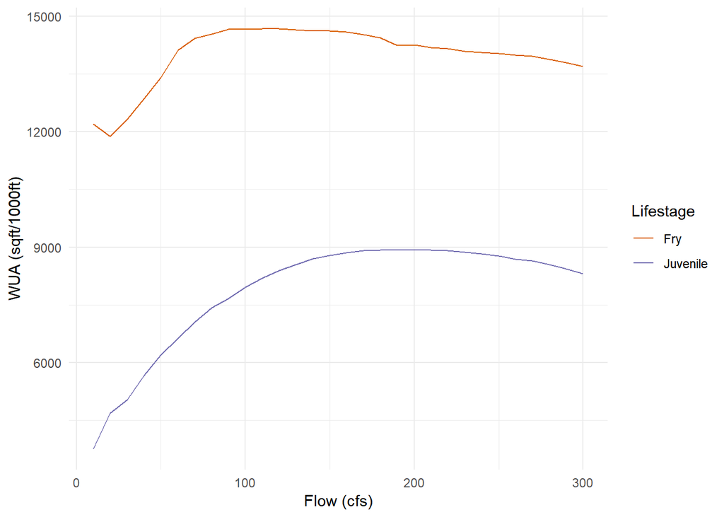